# Homework 2 - Likelihood

Rebecca Amberger and Nora Krebs

12 November 2018

## Likelihood

Tsunami scientist Trevor rolls some dice and tells you that the added result is 17. How many dice did Trevor roll?

Write some **R** code to find out! Think of an example that applies this problem to natural hazards!

#### First idea: using a matrix for the dice roll count

```r
# clear Workspace
rm(list=ls())
# repetition variable for the max. number of dice
x<-17
# repetition variable for the amount of random experiment executions
s<-1000
# creation of an empty matrix with s lines and (x-2) rows
m<-matrix(NA,s,(x-2))

# loop1: repeat the following loop2 s times
for(i in 1:s) {

# creation of an empty vector t with (x-2) digits
t<-rep(NA,(x-2))
# loop2: to roll 3,4,5...,17 dices and adding the random results between 1 and 6
# The sum of each set of dice is then saved in vector t.
for(i in 3:x) {
  t<-sum(sample(1:6, i, replace = TRUE))
}

# each created vector t should fill a line in the matrix
m<-rbind(t[1:s])
}

# The idea was to create 1000 vectors where each vector contained the
# sum of random dice rolls with 1,2,3,4...,17 dices. The goal was to save all
# these vectors in a 1000x15 matrix and let the computer check the results for
# a sum of 17. It was then supposed to extract the number of dices used and
# count them. However, we got convinced that there are better approaches.
```

#### Second idea: programming in two seperate loops

```r
# clear Workspace
rm(list=ls())
# repetition by x times
x<-1000
# creation of an empty vector t with x digits
t<-rep(NA,x)

# first loop: creation of x random dice numbers between 3 and 17, which are
# saved in t
for(i in 1:x) {
  t<-sample(3:17, i, replace = TRUE)
}

# creation of an empty vector s with x digits
s<-rep(NA,x)

# second loop: taking the dice numbers out of vector t one by one, to roll them
# (creating random results between 1 and 6), adding the results and check for the sum of 17
for(i in t[1]:t[x]){
  s<-(sum(sample(1:6, i, replace = TRUE))==17)
}

# At this point we did not know how to correlate vector s and t,
# to find out for which number of dices the sum was 17. In the next step we
# tried to merge the loops to bring the two vectors together.
```

#### Third idea: programming in two merged loops

```r
# clear Workspace
rm(list=ls())
# repetition by x times
x<-1000
# creation of an empty vector t with x digits
t<-rep(NA,x)

# first loop: for creation of x random numbers between 3 and 17, which are
# saved in t (creates a set of random dice numbers)
for(i in 1:x) {
  t<-sample(3:17, i, replace = TRUE)

  # creating an empty vector for saving the results of the merged loop
  s<-rep(NA,x)
  # creation of a second empty vector with x empty digits
  r<-rep(NA,x)
  # second merged loop: for summing up the dice roll numbers
  # t[1]:t[x] was supposed to make sure that i adopts the digit recorded in the
  # corresponding position in vector t. However, this did not work out!
  for(i in t[1]:t[x]) {
    # creation of i random numbers between 1 and 6 and summing them up, placing
    # the result in vector s
    s<-sum(sample(1:6, i, replace = TRUE))
    # if any digit in vector s equals 17, the corresponding digit in the r
    # vector is supposed to equal 1
    r<-(s == 17)
  }

  # Now we encountered our biggest problem, which was that we did not know how
  # to extract the number of dices that have been used to create a sum of 17
  # out of vector t.
  # We got stuck and tried a new approach.
}
```

#### Our final R code modified with the lecture solution

```r
# The introduction of dice min/max variables was a practical idea, which we
# adapted later:
# min_dice <- 3   #min. number of dice
# max_dice <- 17  #max. number of dice
# define number of times the experiment runs
x <- 17000
# simulation of picking a random number of 3 to 17 dice x-times
t <- (sample (3:17, x, replace = T))
# create an empty vector z with x digits
z <- rep(NA,x)
# generate a loop where each random number of dice of vector t is rolled and
# where the random results of 1 to 6 are added up and checked for the sum of
# 17. Where this is the case, the answer is not 0, but the number of dice used
# (as written in vector t).
for(i in 1:x) {
  if(sum(sample (1:6,t[i], replace = T)) == 17) {
    z[i] <- t[i]
  }
}

# New to us was the introduction of an "if" condition and the assignment
# of t values to the z vector ("z[i] <- t[i]").
```

#### Our plot

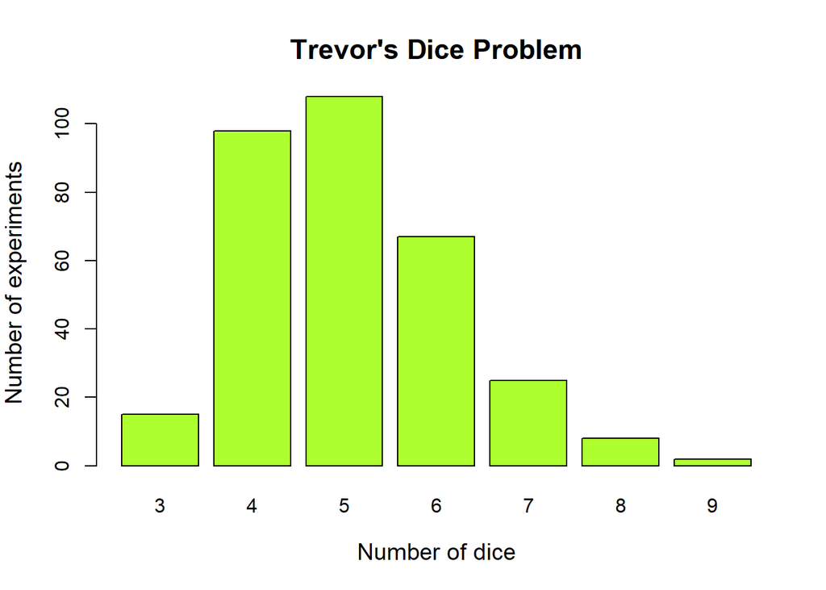

```r
# plot histogram for number of dice and experiments
barplot(table(z), col = "greenyellow", lwd = 1, main = "Trevor's Dice Problem",
     xlab = "Number of dice", ylab = "Number of experiments",
     cex.main = 1.4, cex.lab = 1.2)
```

```r
# col = default plotting color
# lwd = line width relative to default
# main = title
# xlab / ylab = x- / y-axis label
# cex.main / cex.lab = magnification of titel an x- / y-label relative to cex
```

#### Application of the problem in natural hazards

1. Our first idea of a problem in natural hazards that applies to the example above, is about a volcanic eruption or multiple volcanic eruptions that happened in the past and where we have no in-time measurements. Based on our in field observations of volcanic deposits, we know the given area and maybe even a grade of destruction (given result). Consequently, we want to make conclusions about the kind and magnitude of volcanic processes (unknown input), which played a major role during the event. In search for the most probable hazard setting, further important parameters might be the sequence in which volcanic processes took place, as well as the question which vent the hazard originated from (in case there are several volcanic vents in the surroundings).
2. Our second idea is about paleo-tsunamis. In this case the given data would be a paleo-water level line to which the wave of a tsunami traveled (given result). This can be used to draw back conclusions about the wave height at which the tsunami traveled inlands. The parameters we are looking for are the position, the magnitude of the earthquake and the sea floor morphology as well as the vertical displacement of the sea floor that have caused the tsunami (several scenarios might lead to similar results: unknown input). Given the water height and propagation of the tsunami, it would be interesting to find out, if a relatively weak earthquake with a small vertical displacement in shore proximities is more likely or a relatively strong earthquake with a high vertical displacement far away from shore.